# Validation of {recalc} and {reappraised}

Ian Hussey

08 December, 2025

# TODO package

- add one vs two sided p value?
- other versions of d?
- input assumes both Ms and both SDs have identical precision. is this ever violated?
- t = results_original_t, # bounds?
- df = results_original_df) # value?
- consider using scrutiny::restore_zeros in min and max output, using m_digits, sd_digits, and d_digits

# TODO sims

- add welch’s test and unbalanced SDs

# Dependencies

```r
library(tibble)
library(roundwork)
# devtools::install_github("ianhussey/recalc")
library(recalc)

library(tidyr)
library(dplyr)
library(forcats)
library(readr)
library(purrr)
library(furrr)
library(ggplot2)
library(ggstance)
library(scales)
library(knitr)
library(kableExtra)
library(parameters)
library(effectsize)
```

# Functions

```r
# functions for simulation
generate_data <- function(m1,
                          m2,
                          sd1,
                          sd2,
                          n1,
                          n2) {

  data1 <-
    tibble(condition = "1",
           score = rnorm(n = n1, mean = m1, sd = sd1))

  data2 <-
    tibble(condition = "2",
           score = rnorm(n = n2, mean = m2, sd = sd2))

  data_combined <- bind_rows(data1,
                             data2)

  return(data_combined)
}

analyze <- function(data,
                    m_digits,
                    sd_digits,
                    d_digits,
                    p_digits,
                    analysis_rounding) {

  res_summary <- data |>
    group_by(condition) |>
    summarize(m = mean(score),
              sd = sd(score),
              n = n()) |>
    pivot_wider(names_from = condition,
                names_sep = "",
                values_from = c("m", "sd", "n"))

  res_ttest <-
    t.test(formula = score ~ condition,
           data = data,
           var.equal = TRUE,
           alternative = "two.sided") |>
    model_parameters() |>
    as_tibble() |>
    select(t, df = df_error, p)

  res_d <- effectsize::cohens_d(score ~ condition,
                                data = data) |>
    as_tibble() |>
    select(d = Cohens_d,
           d_ci_lower = CI_low,
           d_ci_upper = CI_high)

  res <- bind_cols(res_summary,
                   res_ttest,
                   res_d)

  if(analysis_rounding == "half_up"){
    res <- res |>
      mutate(m1 = round_up(m1, m_digits),
             m2 = round_up(m2, m_digits),
             sd1 = round_up(sd1, sd_digits),
             sd2 = round_up(sd2, sd_digits),
             d = round_up(d, d_digits),
             d_ci_lower = round_up(d_ci_lower, d_digits),
             d_ci_upper = round_up(d_ci_upper, d_digits),
             p = round_up(p, p_digits),
             p_operator = dplyr::if_else(dplyr::near(p, 0), "less_than", "equals"),
             p = dplyr::if_else(dplyr::near(p, 0), 1 * 10^-p_digits, p))
  } else if(analysis_rounding == "half_down"){
    res <- res |>
      mutate(m1 = round_down(m1, m_digits),
             m2 = round_down(m2, m_digits),
             sd1 = round_down(sd1, sd_digits),
             sd2 = round_down(sd2, sd_digits),
             d = round_down(d, d_digits),
             d_ci_lower = round_down(d_ci_lower, d_digits),
             d_ci_upper = round_down(d_ci_upper, d_digits),
             p = round_down(p, p_digits),
             p_operator = dplyr::if_else(dplyr::near(p, 0), "less_than", "equals"),
             p = dplyr::if_else(dplyr::near(p, 0), 1 * 10^-p_digits, p))
  } else if(analysis_rounding == "bankers"){
    res <- res |>
      mutate(m1 = round(m1, m_digits),
             m2 = round(m2, m_digits),
             sd1 = round(sd1, sd_digits),
             sd2 = round(sd2, sd_digits),
             d = round(d, d_digits),
             d_ci_lower = round(d_ci_lower, d_digits),
             d_ci_upper = round(d_ci_upper, d_digits),
             p = round(p, p_digits),
             p_operator = dplyr::if_else(dplyr::near(p, 0), "less_than", "equals"),
             p = dplyr::if_else(dplyr::near(p, 0), 1 * 10^-p_digits, p))
  } else if(analysis_rounding == "trunc"){
    res <- res |>
      mutate(m1 = round_trunc(m1, m_digits),
             m2 = round_trunc(m2, m_digits),
             sd1 = round_trunc(sd1, sd_digits),
             sd2 = round_trunc(sd2, sd_digits),
             d = round_trunc(d, d_digits),
             d_ci_lower = round_trunc(d_ci_lower, d_digits),
             d_ci_upper = round_trunc(d_ci_upper, d_digits),
             p = round_trunc(p, p_digits),
             p_operator = dplyr::if_else(dplyr::near(p, 0), "less_than", "equals"),
             p = dplyr::if_else(dplyr::near(p, 0), 1 * 10^-p_digits, p))
  }

  return(res)
}

reconstruct <- function(results,
                        m_digits,
                        sd_digits,
                        d_digits,
                        p_digits,
                        direction,
                        hedges_correction,
                        include_se_sd_confusion,
                        reconstruct_rounding,
                        output_rounding){
  independent_t_test_summary(
    m1 = results$m1,
    m2 = results$m2,
    sd1 = results$sd1,
    sd2 = results$sd2,
    n1 = results$n1,
    n2 = results$n2,
    d = results$d,
    d_ci_lower = results$d_ci_lower,
    d_ci_upper = results$d_ci_upper,
    p_operator = results$p_operator,
    p = results$p,
    input_rounding = reconstruct_rounding,
    output_rounding = output_rounding,
    m_digits = m_digits,
    sd_digits = sd_digits,
    d_digits = d_digits,
    direction = direction,
    hedges_correction = hedges_correction,
    p_digits = p_digits,
    include_se_sd_confusion = include_se_sd_confusion
  )$reproduced
}



# --- BOLLAND'S REAPPRAISED HELPER FUNCTIONS (abstracted from app_continuous.R) ---

# Generic function to make into long format
lng_f <- function (dat, remvars) {
  b <- dat %>%
    tidyr::gather(v, value, -c(all_of(remvars))) %>%
    tidyr::separate_wider_regex(v, c(var1 = ".", group= "\\d+")) %>%
    tidyr::spread(var1, value) %>% #delete missing data
    dplyr::filter (!is.na(m) & !is.na(s) & !is.na(n))
  return (b)
}

# Calculate the pvalues
pval <- function(df, simulate = "n") {
  if (simulate == "n") {
    df <- df %>% dplyr::group_by(study, var)
  } else {df <- df %>% dplyr::group_by(sim, study, var) }

  df <- df %>%
    dplyr::summarise(
      # Get the # of means and overall mean
      k = dplyr::n(),
      tot_n = sum(n),
      ov_m = sum(n * m) / tot_n,
      # Calculate mean sq between and within
      msb = sum(n * (m - ov_m)^2),
      msw = sum((n - 1) * s^2),
      .groups = "drop"
    ) %>%
    # Filter out cases with insufficient data
    dplyr::filter(k >= 2, tot_n > k) %>%
    dplyr::mutate(
      # Degrees of freedom
      dfb = k - 1,
      dfw = tot_n - k,
      # F-statistic and p-value
      f_value = ifelse(msw > 0, msb/dfb / (msw/dfw), NA),
      p.value = ifelse(!is.na(f_value), pf(f_value, dfb, dfw, lower.tail = FALSE), NA)
    )
```

```r
  if (simulate == "n") {df <- df %>% dplyr::select(study, var, p.value)
  } else {df <- df %>% dplyr::select(study, var, sim, p.value)}
}

# Function to count decimal places
dec_places <- function(a, nm, nm.m, nm.s) {
  a1 <- cbind(a, setNames(lapply(a[nm], dp), paste0("dp", nm)))

  # r and excel don't include final 0s (as numbers) so take maximum dp per variable
  m <- a1[nm.m]
  m[] <- t(apply(m, 1, function(x) ifelse(is.na(x), NA, max(x, na.rm = TRUE))))
  s <- a1[nm.s]
  s[] <- t(apply(s, 1, function(x) ifelse(is.na(x), NA, max(x, na.rm = TRUE))))

  # Replace the columns back in original dataframe
  a1[nm.m] <- m
  a1[nm.s] <- s

  return(a1)
}

# Basic dec places fn
dp <- function (x) {
  ifelse(abs(x- round(x)) > .Machine$double.eps^0.5,
         nchar(sub('^\\d+\\.', '', sub('0+$', '', as.character(abs(x))))), 0)}

# Sig figures function
sigfigs <- function(j, dat) {
  x <- dat[, j]
  sapply(x, function(val) {
    if (is.na(val) || !is.finite(val)) return(NA)
    if (val == 0) return(1L)
    str_val <- sprintf("%g", abs(val))
    cleaned <- gsub("0+$", "", gsub("^0+", "", gsub("\\.", "", str_val)))
    if (cleaned == "") return(1L)
    nchar(cleaned)
  })
}

# Determine combinations of means with max and min weighted mean square error
ms <- function(data) {
  data %>%
    dplyr::group_by(study, var) %>%
    dplyr::group_modify(~ {
      m_vals <- .x$m
      n_vals <- .x$n
      df_vals <- .x$dfm

      combs <- expand.grid(lapply(1:length(m_vals), function(i) {
        c(m_vals[i] + df_vals[i], m_vals[i] - df_vals[i])
      }))

      ms <- apply(combs, 1, function(m_comb) {
        tot_n <- sum(n_vals)
        ov_m <- sum(n_vals * m_comb) / tot_n
        ms <- sum(n_vals * (m_comb - ov_m)^2)
        return(ms)
      })

      m_cols <- combs
      colnames(m_cols) <- paste0("m", 1:ncol(combs))

      df <- data.frame(
        ms = ms,
        m_cols
      ) %>%
        dplyr::mutate(stat = dplyr::case_when(ms == max(ms) ~ "max", ms == min(ms) ~ "min", .default = "")) %>%
        dplyr::filter(stat %in% c("max", "min")) %>% dplyr::distinct(ms, stat, .keep_all = TRUE)
    })
}

# Work out how much to round values
max_round <- function(x, dpm, sig_figs) {
  dat <- data.frame(x = x, dpm = dpm, sig_figs = sig_figs) %>%
    dplyr::mutate(z = dplyr::case_when(is.na(x) ~ NA, x == 0 ~ 0.5,
                                       abs(x) >= 1 ~ {magnitude <- floor(log10(abs(x)))
                                       least_sig_position <- magnitude - sig_figs + 1
                                       max_val <- abs(x) + 0.5 * 10^least_sig_position
                                       max_val - abs(x)},
                                       abs(x) < 1 ~ 0.5 * 10^(-dpm), .default = x))
  return(dat$z)
}

# Function to work out max and min p-value
# Function to work out max and min p-value
rng_p_fn <- function (dat, nm, nm_m, nm_s, nm_n, nm.m, nm.s, nm.sf) {

  am <- dat
  rng <- dec_places(am, nm, nm.m, nm.s)
  rng [, nm.sf] <- lapply(nm, function(x) sigfigs(x, rng))

  nm.dtm <- paste0(nm_m, "dt")
  nm.dts <- paste0(nm_s, "dt")
  rng [, c(nm.dtm,nm.dts) ] <- rng [, c(nm_m, nm_s)]

  rng <- rng %>%
    dplyr::mutate (dpm = do.call(pmax, c(dplyr::select(., all_of(nm.m)), na.rm = T)),
                   dps = do.call(pmax, c(dplyr::select(., all_of(nm.s)), na.rm = T)),
                   sfm = do.call(pmax, c(dplyr::select(., paste0(nm_m, "_sf")), na.rm = T)),
                   sfs = do.call(pmax, c(dplyr::select(., paste0(nm_s, "_sf")), na.rm = T))) %>%
    dplyr::select (-c(all_of(nm.m), all_of(nm.s), all_of(nm.sf)))

  rng <-  rng %>% dplyr::mutate (across(all_of(nm.dtm), ~ max_round(.x, dpm, sfm)),
                                 across(all_of(nm.dts), ~ max_round(.x, dps, sfs))) %>%
    dplyr::mutate (dfm = do.call(pmax, c(dplyr::select(., all_of(nm.dtm)), na.rm = T)),
                   dfs = do.call(pmax, c(dplyr::select(., all_of(nm.dts)), na.rm = T)))

  b <- lng_f(am %>% dplyr::select(-any_of("p")), remvars = c("study","var"))
  b <- b %>% dplyr::left_join (rng %>% dplyr::select(study, var, dfm), by =c("study", "var"))

  b2 <- ms (b)

  b_max <- dplyr::left_join (rng %>% dplyr::select (-all_of(nm_m)),
                             b2 %>% dplyr::filter (stat == "max") %>% dplyr::select(study, var, all_of (nm_m)),
                             by = c("study", "var")) %>%
    dplyr::select(- c(any_of("p"), all_of(nm.dtm), all_of(nm.dts), dpm:sfs)) %>%
    dplyr::mutate (across(all_of(nm_s), ~ .x - dfs))

  b_min <- dplyr::left_join (rng %>% dplyr::select (-all_of(nm_m)),
                             b2 %>% dplyr::filter (stat == "min") %>% dplyr::select(study, var, all_of (nm_m)),
                             by = c("study", "var")) %>%
    dplyr::select(- c(any_of("p"), all_of(nm.dtm), all_of(nm.dts), dpm:sfs)) %>%
    dplyr::mutate (across(all_of(nm_s), ~ .x + dfs))

  b_max1 <- lng_f (b_max, remvars = c("study", "var", "dfs", "dfm"))
  b_max1 <- pval(b_max1)

  b_min1 <- lng_f (b_min, remvars = c("study", "var", "dfs", "dfm"))
  b_min1 <- pval(b_min1)

  rng_data <- dplyr::bind_rows (dplyr::left_join(b_max, b_max1 %>% dplyr::rename (p_min = p.value) %>%
                                                   dplyr::mutate (stat = "min_p-value"), by = c("study", "var")),
                                dplyr::left_join(b_min, b_min1 %>% dplyr::rename (p_max = p.value) %>%
                                                   dplyr::mutate (stat = "max_p-value"), by = c("study", "var"))) %>%
    dplyr::mutate (p_range = dplyr::coalesce(p_min, p_max))

  return (rng_data)
}


reconstruct_bolland <- function(results) {

  # 1. Structure the data exactly as Bolland's 'base_p_cont' expects
  # Note: Bolland's app cleans column names before this step; here we construct them directly.
  df_bolland <- tibble::tibble(
    study = "sim_study",
    var = "sim_var",
    m1 = results$m1,
    s1 = results$sd1,
    n1 = results$n1,
    m2 = results$m2,
    s2 = results$sd2,
    n2 = results$n2
  )

  # 2. Define the name vectors logic normally found in 'base_p_cont'
  # We hardcode these for 2 groups as per your simulation structure
  nm <- c("m1", "s1", "m2", "s2")
  nm_m <- c("m1", "m2")
  nm_s <- c("s1", "s2")
  nm_n <- c("n1", "n2")
  nm.m <- paste0("dp", nm_m)
  nm.s <- paste0("dp", nm_s)
  nm.sf <- paste0(nm, "_sf")
```

```r
  # 3. Run Bolland's core logic 'rng_p_fn'
  # We suppress warnings because his code often throws warnings during loop combinations
  rng_data <- suppressWarnings(
    rng_p_fn(dat = df_bolland,
             nm, nm_m, nm_s, nm_n, nm.m, nm.s, nm.sf)
  )

  # 4. Extract Min and Max P-values
  # rng_data returns two rows (one for min scenario, one for max scenario)
  # p_min is found in the 'min_p-value' row, p_max in the 'max_p-value' row.
  # Note: His code calculates p_min as the result of the max difference, and vice versa.

  min_p_val <- rng_data |>
    dplyr::filter(stat == "min_p-value") |>
    dplyr::pull(p_min)

  max_p_val <- rng_data |>
    dplyr::filter(stat == "max_p-value") |>
    dplyr::pull(p_max)

  # 5. Check if reported P is in bounds (Logic adapted from 'chk_pvals')
  p_reported <- results$p
  p_inbounds <- (p_reported >= min_p_val) & (p_reported <= max_p_val)

  # 6. Return tibble matching your simulation format
  tibble::tibble(
    p_min_bolland = min_p_val,
    p_max_bolland = max_p_val,
    p_inbounds_bolland = p_inbounds
  )
}

# naive p and d ignoring rounding
# modified from internal {recalc} functions .calculate_cohen_d_stats() and .calculate_student_t().
calculate_naive_d_and_t <- function(results) {

  df <- tibble::tibble(
    m1 = results$m1,
    sd1 = results$sd1,
    n1 = results$n1,
    m2 = results$m2,
    sd2 = results$sd2,
    n2 = results$n2
  )

  # Mean diff
  diff_mean <- df$m1 - df$m2

  # Pooled SD and DF (needed for student t and d)
  df_s <- df$n1 + df$n2 - 2

  sp   <- sqrt(((df$n1 - 1) * df$sd1^2 + (df$n2 - 1) * df$sd2^2) / df_s)
  # Raw d
  d_raw <- diff_mean / sp

  # Standard Error
  se_pooled <- sp * sqrt(1 / df$n1 + 1 / df$n2)
  t_val     <- diff_mean / se_pooled
  p_val     <- 2 * (1 - pt(abs(t_val), df = df_s))

  # Return everything needed for downstream calculations
  data.frame(
    naive_d = d_raw,
    naive_p = p_val
  )
}
```

# Run simulation

```r
if(file.exists("simulation.rds")){
  simulation <- read_rds("simulation.rds")
} else {

  # simulation parameters
  experiment_parameters <- expand_grid(
    pop_m1 = 0,
    pop_m2 = c(0, 2),
    pop_sd1 = 1,
    pop_sd2 = 1,
    pop_n1 = 25,
    pop_n2 = 25,
    m_digits = 2,
    sd_digits = 2,
    d_digits = 2,
    p_digits = 3,
    analysis_rounding = c("half_up", "half_down", "bankers", "trunc"),
    reconstruct_rounding = c("truncated", "rounded"),
    output_rounding = c("half_up", "half_down", "bankers", "trunc"),
    include_se_sd_confusion = FALSE,
    direction = "m1_minus_m2",
    hedges_correction = FALSE,
    iteration = 1:1000
  )

  # set up parallelization
  plan(multisession, workers = future::availableCores())

  # set seed
  set.seed(42)

  # run simulation
  simulation <- experiment_parameters |>
    # generate datasets
    mutate(generated_data = future_pmap(.l = list(m1 = pop_m1,
                                                  m2 = pop_m2,
                                                  sd1 = pop_sd1,
                                                  sd2 = pop_sd2,
                                                  n1 = pop_n1,
                                                  n2 = pop_n2),
                                        .f = generate_data,
                                        .progress = TRUE,
                                        .options = furrr_options(seed = TRUE))) |>
    # analyze data to create the real p and d values and summary stats
    mutate(results_original = future_pmap(.l = list(data = generated_data,
                                                    m_digits = m_digits,
                                                    sd_digits = sd_digits,
                                                    d_digits = d_digits,
                                                    p_digits = p_digits,
                                                    analysis_rounding = analysis_rounding),
                                          .f = analyze,
                                          .progress = TRUE,
                                          .options = furrr_options(seed = TRUE))) |>
    # use recalc to reconstruct the p and d bounds
    mutate(results_reconstructed = future_pmap(.l = list(results = results_original,
                                                         m_digits = m_digits,
                                                         sd_digits = sd_digits,
                                                         d_digits = d_digits,
                                                         p_digits = p_digits,
                                                         direction = direction,
                                                         hedges_correction = hedges_correction,
                                                         include_se_sd_confusion = include_se_sd_confusion,
                                                         reconstruct_rounding = reconstruct_rounding,
                                                         output_rounding = output_rounding),
                                               .f = reconstruct,
                                               .progress = TRUE,
                                               .options = furrr_options(seed = TRUE))) |>
    unnest(results_reconstructed) |>
    mutate(d_beyond_bounds = case_when(d < min_d_rounded ~ d-min_d_rounded,
                                       d > max_d_rounded ~ max_d_rounded-d,
                                       TRUE ~ 0),
           d_abs_beyond_bounds = abs(d_beyond_bounds),
           p_beyond_bounds = case_when(p < min_p_rounded ~ p-min_p_rounded,
                                       p > max_p_rounded ~ max_p_rounded-p,
                                       TRUE ~ 0),
           p_abs_beyond_bounds = abs(p_beyond_bounds)) |>

    # use reappraised to reconstruct the p bounds
    mutate(results_reconstructed_bolland = future_pmap(.l = list(results = results_original),
                                                       .f = reconstruct_bolland,
                                                       .progress = TRUE,
                                                       .options = furrr_options(seed = TRUE))) |>
    unnest(results_reconstructed_bolland) |>
    mutate(p_beyond_bounds_bolland = case_when(p < p_min_bolland ~ p-p_min_bolland,
                                               p > p_max_bolland ~ p_max_bolland-p,
                                               TRUE ~ 0),
           p_abs_beyond_bounds_bolland = abs(p_beyond_bounds_bolland)) |>

    # reconstruct the p and d naively without accounting for rounding or analytic flexibility
    mutate(results_naive = future_map(.x = results_original,
                                      .f = calculate_naive_d_and_t,
                                      .progress = TRUE,
                                      .options = furrr_options(seed = TRUE))) |>
    # unnest results
    unnest(results_naive) |>
    mutate(p_naive_p_diff = naive_p - p,
           d_naive_d_diff = naive_d - d)

  write_rds(simulation, "simulation.rds", compress = "gz")

}
```

# Summarize results

## recalc’s coverage

All results

```r
simulation_coverage <- simulation |>
  #group_by(pop_es = pop_m2, analysis_rounding, reconstruct_rounding, output_rounding) |>
  summarize(
    coverage_p_recalc = mean(p_inbounds),
    #max_p_abs_beyond_bounds = max(p_abs_beyond_bounds),
    coverage_p_bolland = mean(p_inbounds_bolland),
    #max_p_abs_beyond_bounds_bolland = max(p_abs_beyond_bounds_bolland)
    coverage_d_recalc = mean(d_inbounds)
    #max_d_abs_beyond_bounds = max(d_abs_beyond_bounds)
  )

simulation_coverage |>
  kable() |>
  kable_classic(full_width = FALSE)
```

[output not shown]

By factorial, only cells with imperfect coverage

```r
simulation_coverage_by <- simulation |>
  group_by(pop_es = pop_m2, analysis_rounding, reconstruct_rounding, output_rounding) |>
  summarize(
    coverage_p_recalc = mean(p_inbounds),
    #max_p_abs_beyond_bounds = max(p_abs_beyond_bounds),
    coverage_p_bolland = mean(p_inbounds_bolland),
    #max_p_abs_beyond_bounds_bolland = max(p_abs_beyond_bounds_bolland)
    coverage_d_recalc = mean(d_inbounds)
    #max_d_abs_beyond_bounds = max(d_abs_beyond_bounds)
  )

simulation_coverage_by |>
  filter(!near(coverage_p_recalc, 1)) |>
  kable() |>
  kable_classic(full_width = FALSE)
```

| pop_es | analysis_rounding | reconstruct_rounding | output_rounding | coverage_p_recalc | coverage_p_bolland | coverage_d_recalc |
| --- | --- | --- | --- | --- | --- | --- |
| 0 | bankers | truncated | trunc | 0.999 | 0.981 | 1.000 |
| 0 | half_down | rounded | trunc | 0.997 | 0.979 | 0.991 |
| 0 | trunc | rounded | bankers | 0.870 | 0.856 | 0.991 |
| 0 | trunc | rounded | half_down | 0.870 | 0.862 | 0.991 |
| 0 | trunc | rounded | half_up | 0.860 | 0.846 | 0.991 |
| 0 | trunc | rounded | trunc | 0.902 | 0.864 | 0.971 |
| 2 | bankers | rounded | trunc | 0.998 | 0.017 | 1.000 |
| 2 | half_down | rounded | trunc | 0.999 | 0.012 | 0.999 |
| 2 | half_down | truncated | trunc | 0.998 | 0.010 | 1.000 |
| 2 | half_up | rounded | trunc | 0.998 | 0.013 | 1.000 |

By factorial, only cells with imperfect coverage, output_rounding != “trunc”

```r
simulation_coverage_by |>
  filter(output_rounding != "trunc") |>
  filter(!near(coverage_p_recalc, 1)) |>
  kable() |>
  kable_classic(full_width = FALSE)
```

| pop_es | analysis_rounding | reconstruct_rounding | output_rounding | coverage_p_recalc | coverage_p_bolland | coverage_d_recalc |
| --- | --- | --- | --- | --- | --- | --- |
| 0 | trunc | rounded | bankers | 0.87 | 0.856 | 0.991 |
| 0 | trunc | rounded | half_down | 0.87 | 0.862 | 0.991 |
| 0 | trunc | rounded | half_up | 0.86 | 0.846 | 0.991 |

By factorial, only cells with imperfect coverage, output_rounding != “trunc” & reconstruct_rounding == “truncated”

```r
simulation_coverage_by |>
  filter(output_rounding != "trunc" &
           reconstruct_rounding == "truncated")  |>
  kable() |>
  kable_classic(full_width = FALSE)
```

| pop_es | analysis_rounding | reconstruct_rounding | output_rounding | coverage_p_recalc | coverage_p_bolland | coverage_d_recalc |
| --- | --- | --- | --- | --- | --- | --- |
| 0 | bankers | truncated | bankers | 1 | 0.972 | 1 |
| 0 | bankers | truncated | half_down | 1 | 0.986 | 1 |
| 0 | bankers | truncated | half_up | 1 | 0.982 | 1 |
| 0 | half_down | truncated | bankers | 1 | 0.978 | 1 |
| 0 | half_down | truncated | half_down | 1 | 0.982 | 1 |
| 0 | half_down | truncated | half_up | 1 | 0.985 | 1 |
| 0 | half_up | truncated | bankers | 1 | 0.986 | 1 |
| 0 | half_up | truncated | half_down | 1 | 0.989 | 1 |
| 0 | half_up | truncated | half_up | 1 | 0.981 | 1 |
| 0 | trunc | truncated | bankers | 1 | 0.877 | 1 |
| 0 | trunc | truncated | half_down | 1 | 0.863 | 1 |
| 0 | trunc | truncated | half_up | 1 | 0.848 | 1 |
| 2 | bankers | truncated | bankers | 1 | 0.018 | 1 |
| 2 | bankers | truncated | half_down | 1 | 0.013 | 1 |
| 2 | bankers | truncated | half_up | 1 | 0.013 | 1 |
| 2 | half_down | truncated | bankers | 1 | 0.019 | 1 |
| 2 | half_down | truncated | half_down | 1 | 0.009 | 1 |
| 2 | half_down | truncated | half_up | 1 | 0.016 | 1 |
| 2 | half_up | truncated | bankers | 1 | 0.017 | 1 |
| 2 | half_up | truncated | half_down | 1 | 0.012 | 1 |
| 2 | half_up | truncated | half_up | 1 | 0.014 | 1 |
| 2 | trunc | truncated | bankers | 1 | 0.022 | 1 |
| 2 | trunc | truncated | half_down | 1 | 0.028 | 1 |
| 2 | trunc | truncated | half_up | 1 | 0.024 | 1 |

- This shows that reconstruct_rounding==“truncated” & output_rounding==NULL (or even any one of them) gives perfect coverage is output_rounding even needed? intuitively yes, so why not in practice? in subsequent analyses, examine only one output rounding, round_up.

Imperfect coverage is expected when the analysis was reported using truncation (offset up to ±.01) but the reconstruction was done using rounding (offset up to ±.005):

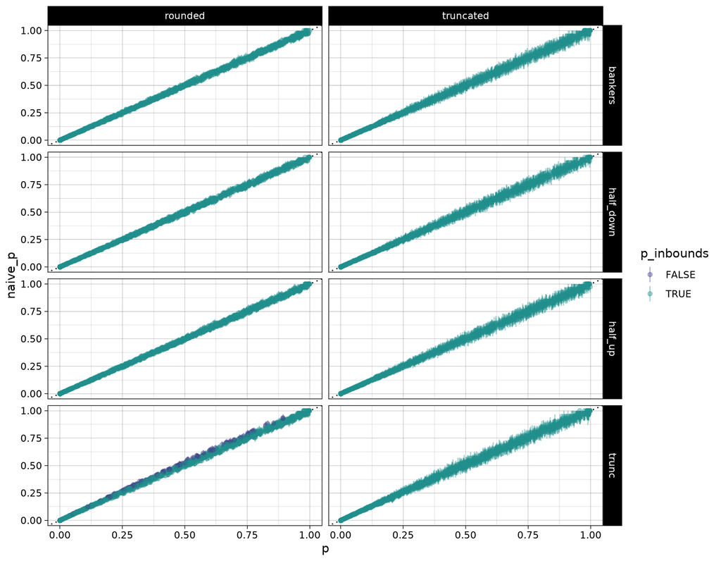

```r
simulation|>
  filter(output_rounding == "half_up") |>
  ggplot(aes(x = p, y = naive_p, color = p_inbounds)) +
  geom_abline(slope = 1, linetype = "dotted") +
  geom_linerange(aes(ymin = min_p_rounded, ymax = max_p_rounded), alpha = 0.4) +
  geom_point(alpha = 0.4) +
  scale_color_viridis_d(begin = 0.2, end = .5) +
  theme_linedraw() +
  facet_grid(analysis_rounding ~ reconstruct_rounding)
```

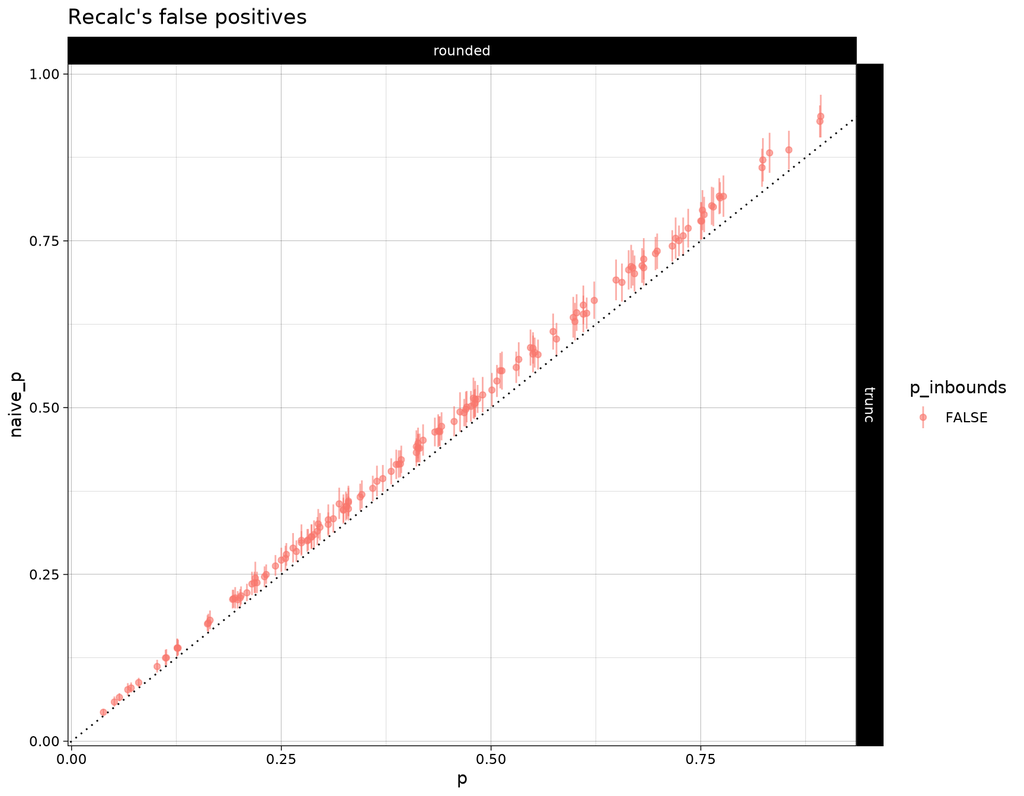

```r
simulation |>
  filter(output_rounding == "half_up") |>
  filter(!p_inbounds) |>
  ggplot(aes(x = p, y = naive_p, color = p_inbounds)) +
  geom_abline(slope = 1, linetype = "dotted") +
  geom_linerange(aes(ymin = min_p_rounded, ymax = max_p_rounded), alpha = 0.6) +
  geom_point(alpha = 0.6) +
  theme_linedraw() +
  facet_grid(analysis_rounding ~ reconstruct_rounding) +
  ggtitle("Recalc's false positives")
```

```r
# simulation |>
#   mutate(p_bounds_width = max_p_rounded - min_p_rounded) |>
#   group_by(reconstruct_rounding, analysis_rounding, output_rounding) |> #
#   summarize(
#     mean_p_bounds_width = mean(p_bounds_width),
#   ) |>
#   kable() |>
#   kable_classic(full_width = FALSE)

simulation |>
  filter(output_rounding == "half_up") |>
  mutate(p_bounds_width = max_p_rounded - min_p_rounded) |>
  group_by(reconstruct_rounding) |> #
  summarize(
    mean_p_bounds_width = mean(p_bounds_width),
  ) |>
  kable() |>
  kable_classic(full_width = FALSE)
```

| reconstruct_rounding | mean_p_bounds_width |
| --- | --- |
| rounded | 0.0214191 |
| truncated | 0.0422079 |

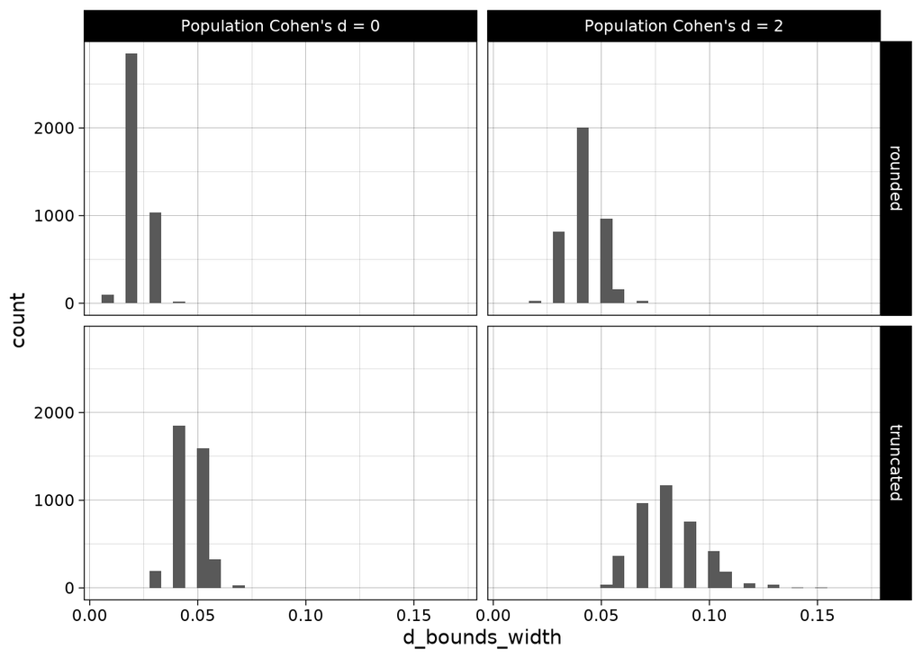

```r
simulation2 <- simulation |>
  filter(output_rounding == "half_up") |>
  mutate(d_bounds_width = max_d_rounded - min_d_rounded,
         p_bounds_width = max_p_rounded - min_p_rounded) |>
  mutate(population_d = paste0("Population Cohen's d = ", pop_m2)) |>
  group_by(population_d,
           reconstruct_rounding) |>
  arrange(p) |>
  mutate(row = row_number())

ggplot(simulation2, aes(d_bounds_width)) +
  geom_histogram(boundary = 0) +
  facet_grid(reconstruct_rounding ~ population_d) +
  theme_linedraw()
```

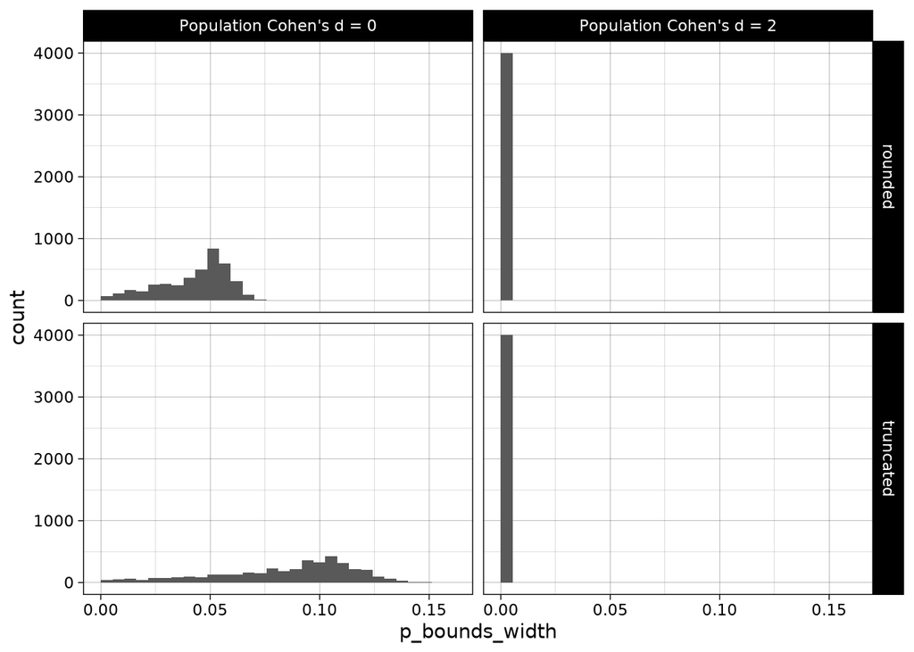

```r
ggplot(simulation2, aes(p_bounds_width)) +
  geom_histogram(boundary = 0) +
  facet_grid(reconstruct_rounding ~ population_d) +
  theme_linedraw()
```

## reappraised’s coverage

only output_rounding == “half_up”

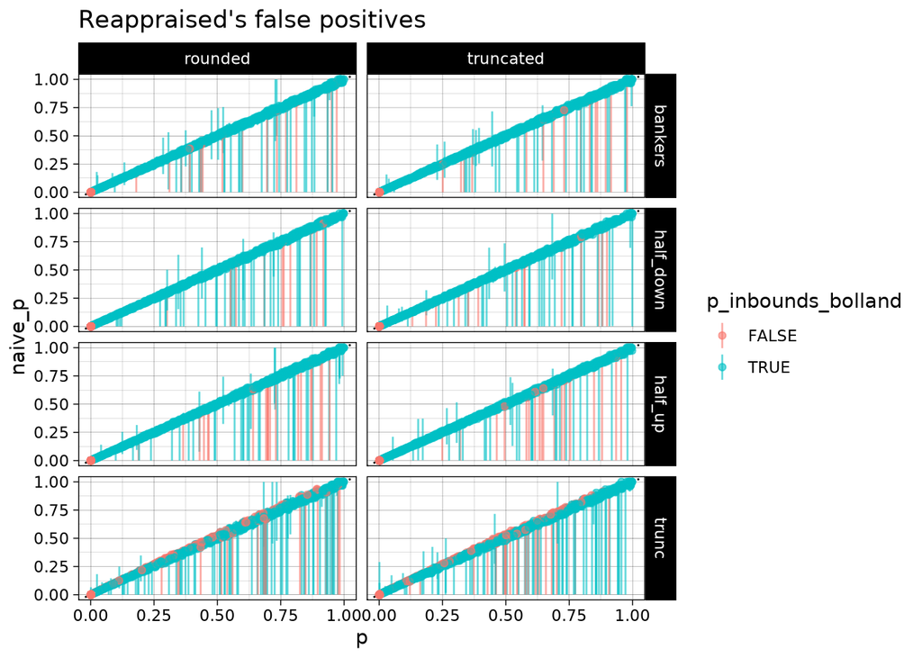

```r
simulation |>
  filter(output_rounding == "half_up") |>
  #filter(!p_inbounds_bolland) |>
  ggplot(aes(x = p, y = naive_p, color = p_inbounds_bolland)) +
  geom_abline(slope = 1, linetype = "dotted") +
  geom_linerange(aes(ymin = p_min_bolland, ymax = p_max_bolland), alpha = 0.6) +
  geom_point(alpha = 0.6) +
  theme_linedraw() +
  facet_grid(analysis_rounding ~ reconstruct_rounding) +
  ggtitle("Reappraised's false positives")
```

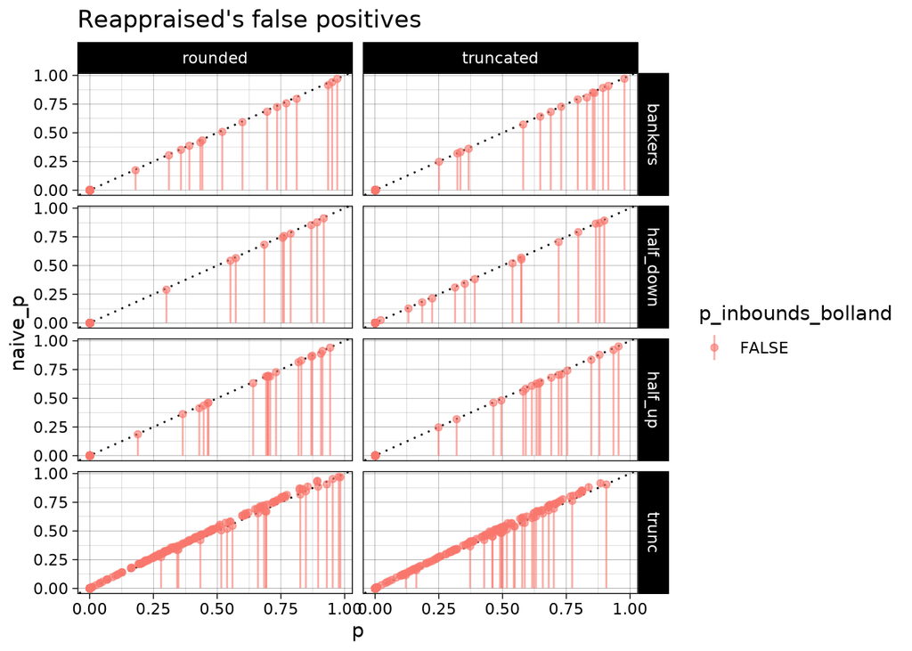

```r
simulation |>
  filter(output_rounding == "half_up") |>
  filter(!p_inbounds_bolland) |>
  ggplot(aes(x = p, y = naive_p, color = p_inbounds_bolland)) +
  geom_abline(slope = 1, linetype = "dotted") +
  geom_linerange(aes(ymin = p_min_bolland, ymax = p_max_bolland), alpha = 0.6) +
  geom_point(alpha = 0.6) +
  theme_linedraw() +
  facet_grid(analysis_rounding ~ reconstruct_rounding) +
  ggtitle("Reappraised's false positives")
```

### Example of a dataset that generates an incorrect conclusion (false positive inconsistency)

In this case, it’s probably due to the means both having trailing zeros, which reappraisal’s code doesn’t catch (i.e., it seems to incorrectly treat “1.00” as if it is “1”, with downstream impact on the calculated bounds).

```r
reappraised_example <- simulation |>
  filter(analysis_rounding == "half_up" & reconstruct_rounding == "rounded") |>
  arrange(desc(p_abs_beyond_bounds_bolland)) |>
  slice(1:1) |>
  unnest(results_original, names_sep = "_") |>
  select(m1 = results_original_m1,
         m2 = results_original_m2,
         sd1 = results_original_sd1,
         sd2 = results_original_sd2,
         n1 = results_original_n1,
         n2 = results_original_n2,
         p = results_original_p,
         recalc_p_min_rounded = min_p_rounded,
         recalc_p_max_rounded = max_p_rounded,
         recalc_p_inbounds = p_inbounds,
         bolland_p_min = p_min_bolland,
         bolland_p_max = p_max_bolland,
         bolland_p_inbounds = p_inbounds_bolland,
         analysis_rounding)

reappraised_example |>
  kable() |>
  kable_classic(full_width = FALSE)
```

| m1 | m2 | sd1 | sd2 | n1 | n2 | p | recalc_p_min_rounded | recalc_p_max_rounded | recalc_p_inbounds | bolland_p_min | bolland_p_max | bolland_p_inbounds | analysis_rounding |
| --- | --- | --- | --- | --- | --- | --- | --- | --- | --- | --- | --- | --- | --- |
| 0.1 | 0 | 1.01 | 0.7 | 25 | 25 | 0.707 | 0.655 | 0.718 | TRUE | 0.000043 | 0.6875764 | FALSE | half_up |

```r
write_csv(reappraised_example, "reappraised_example.csv")



reappraised_example_data <- simulation |>
  filter(analysis_rounding == "half_up" & reconstruct_rounding == "rounded") |>
  arrange(desc(p_abs_beyond_bounds_bolland)) |>
  slice(1:1) |>
  select(generated_data) |>
  unnest(generated_data)

reappraised_example_data |>
  kable() |>
  kable_classic(full_width = FALSE)
```

| condition | score |
| --- | --- |
| 1 | 1.7541663 |
| 1 | 0.9303346 |
| 1 | 0.6288612 |
| 1 | 0.7329751 |
| 1 | 1.1573816 |
| 1 | 0.6165842 |
| 1 | 0.6840189 |
| 1 | 0.8245865 |
| 1 | -0.3250319 |
| 1 | -1.4252482 |
| 1 | -1.6875166 |
| 1 | -0.8107731 |
| 1 | 0.1433299 |
| 1 | -0.7995710 |
| 1 | -0.1975615 |
| 1 | -0.7535531 |
| 1 | 0.9484186 |
| 1 | 1.4384759 |
| 1 | 0.6147714 |
| 1 | -1.7029083 |
| 1 | -0.1455936 |
| 1 | 0.2844204 |
| 1 | 0.6045358 |
| 1 | 0.5978320 |
| 1 | -1.7105357 |
| 2 | -0.0141482 |
| 2 | 0.4578183 |
| 2 | 1.7897397 |
| 2 | 0.2393846 |
| 2 | -0.4383751 |
| 2 | -1.1101948 |
| 2 | -0.7802310 |
| 2 | -0.2911852 |
| 2 | 0.4000417 |
| 2 | -0.3450102 |
| 2 | 0.3377798 |
| 2 | 0.0664139 |
| 2 | 0.7369267 |
| 2 | -0.7562996 |
| 2 | -1.1031453 |
| 2 | 0.9756796 |
| 2 | 0.1349378 |
| 2 | -0.6758992 |
| 2 | -0.2201411 |
| 2 | -0.1158927 |
| 2 | -0.7785635 |
| 2 | 0.4879486 |
| 2 | 0.5934175 |
| 2 | 0.8396554 |
| 2 | -0.3512833 |

```r
write_csv(reappraised_example_data, "reappraised_example_data.csv")

reappraised_example_data |>
  group_by(condition) |>
  summarize(n = n(),
            mean = mean(score),
            sd = sd(score)) |>
  mutate_if(is.numeric, roundwork::round_down, digits = 2) |>
  kable() |>
  kable_classic(full_width = FALSE)
```

| condition | n | mean | sd |
| --- | --- | --- | --- |
| 1 | 25 | 0.1 | 1.01 |
| 2 | 25 | 0.0 | 0.70 |

## Precision and bias of naive values

```r
simulation |>
  filter(output_rounding == "half_up") |>
  #group_by(pop_m2, reconstruct_rounding, analysis_rounding, output_rounding) |>
  #group_by(pop_m2) |>
  summarise(p_bias_mean = mean(p_naive_p_diff),
            p_accuracy_rmse = sqrt(mean(p_naive_p_diff^2)),
            p_accuracy_abs_max = max(abs(p_naive_p_diff)),
            d_bias_mean = mean(d_naive_d_diff),
            d_accuracy_rmse = sqrt(mean(d_naive_d_diff^2)),
            d_accuracy_abs_max = max(abs(d_naive_d_diff))) |>
  mutate_if(is.numeric, round_up, digits = 3) |>
  kable() |>
  kable_classic(full_width = FALSE)
```

| p_bias_mean | p_accuracy_rmse | p_accuracy_abs_max | d_bias_mean | d_accuracy_rmse | d_accuracy_abs_max |
| --- | --- | --- | --- | --- | --- |
| 0 | 0.008 | 0.05 | -0.001 | 0.007 | 0.038 |

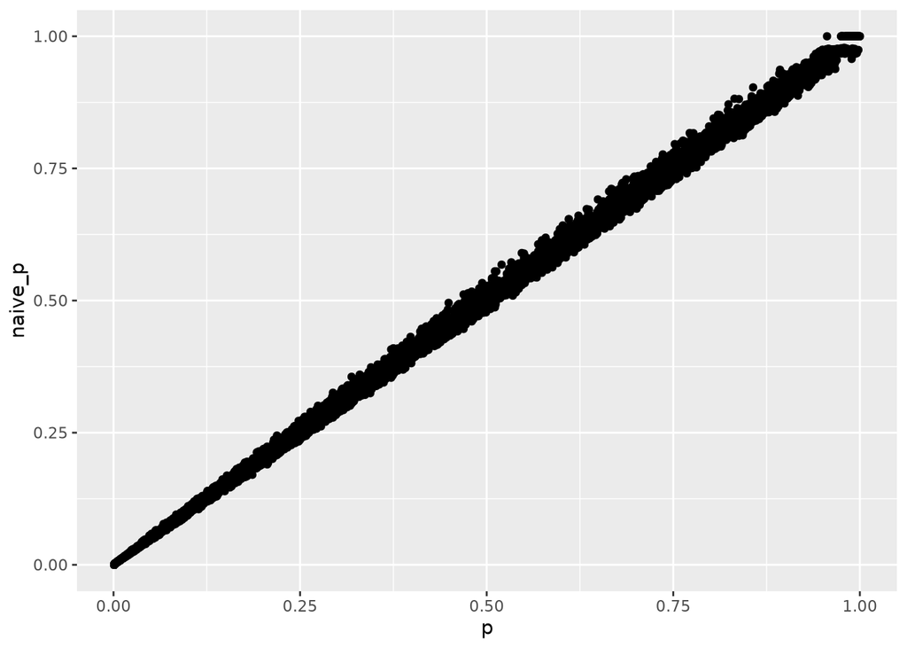

```r
simulation |>
  filter(output_rounding == "half_up") |>
  ggplot(aes(p, naive_p)) +
  geom_point()
```

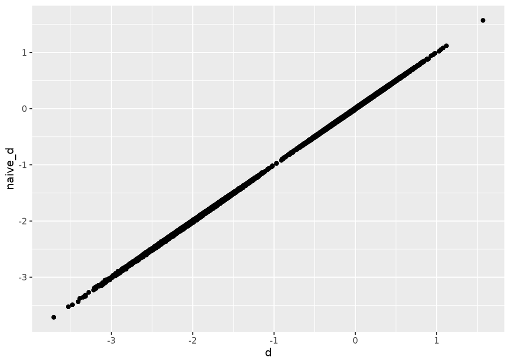

```r
simulation |>
  filter(output_rounding == "half_up") |>
  ggplot(aes(d, naive_d)) +
  geom_point()
```

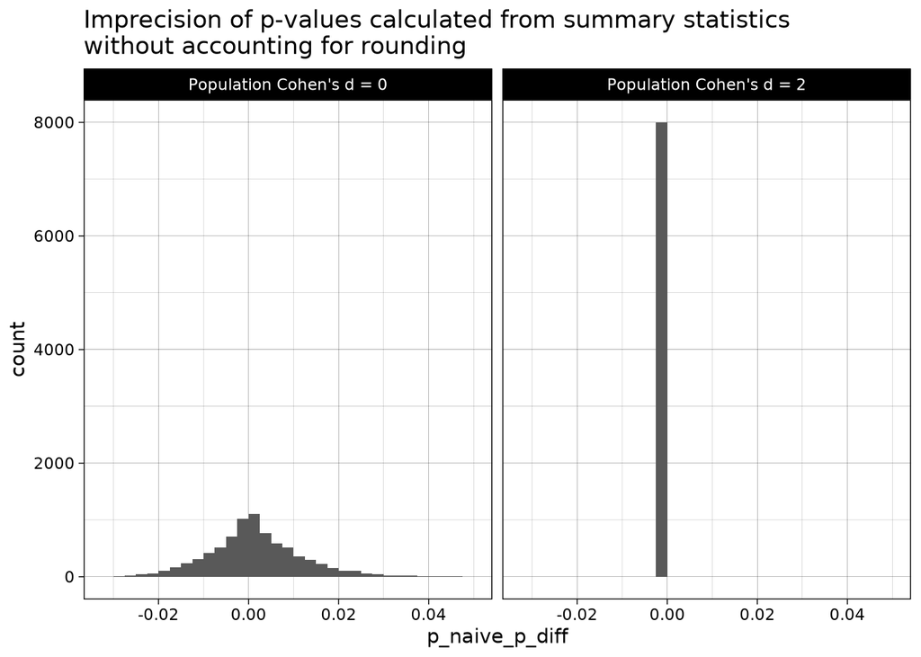

```r
simulation |>
  filter(output_rounding == "half_up") |>
  mutate(population_d = paste0("Population Cohen's d = ", pop_m2)) |>
  ggplot(aes(p_naive_p_diff)) +
  geom_histogram(binwidth = 0.0025, boundary = 0) +
  theme_linedraw() +
  ggtitle("Imprecision of p-values calculated from summary statistics\nwithout accounting for rounding") +
  facet_wrap(~ population_d)
```

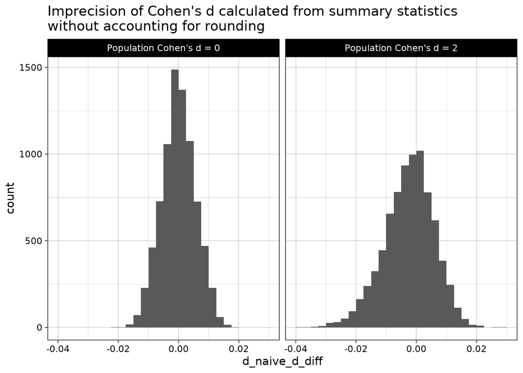

```r
simulation |>
  filter(output_rounding == "half_up") |>
  mutate(population_d = paste0("Population Cohen's d = ", pop_m2)) |>
  ggplot(aes(d_naive_d_diff)) +
  geom_histogram(binwidth = 0.0025, boundary = 0) +
  theme_linedraw() +
  ggtitle("Imprecision of Cohen's d calculated from summary statistics\nwithout accounting for rounding") +
  facet_wrap(~ population_d)
```